# January 2024 draft results

Kristin Dobbin

2024-1-26

## Background, research questions and hypotheses

California has 2967 Community Water Systems (CWS) (including CWS on Tribal lands regulated directly by EPA Region 9). These systems operate under a wide diversity of governance arrangements as detailed by Dobbin & Fencl (2021). Governance type, in turn, corresponds with a variety of important institutional considerations including how decisions are made, the structure (and even existence) of the governing board, and how the governing board is selected and by who.

Recent years have seen a growth of scholarship related to the fundamental importance of good water governance, but, in part due to a lack of data, little research has considered these questions at the water system scale. Nonetheless, high-profile cases like the poisoning of thousands in Flint Michigan highlight the ongoing importance of transparent, representative, and accountable local leadership for water justice.

To begin addressing this gap, this paper aims to describe and quantify diversity in arrangements for representing customers in the decision-making of Community Water Systems (hereafter “enfranchisement”) and explore any potential associations with system performance (see discussion of performance measure below). Specifically, we ask: 1) How are drinking water customers represented in decision-making in non-ancillary Community Water Systems in California?; and 2) Is customer enfranchisement associated with system performance?

Regarding the second question, we expect that greater customer enfranchisement will be associated improved performance and that this association will be strongest for performance measures that relate to affordability and access to public funding.

## Data Summary

Our initial sample is 2458 of the total 2967 Community Water Systems (CWS) in California. This sample excludes the 108 CWS on Tribal lands regulated directly by EPA region 9 as well as ancillary water systems serving state, federal or county facilities (e.g. prisons, county owned housing), schools and privately owned ancillary facilities (retreat centers, churches, packing houses, farmworker housing etc.). We exclude the former due to their unique governance and regulatory nature. We exclude the later due to the fact that such ancillary systems are not governed by boards (these rationale’s need improvement, technically MHPs aren’t governed by boards either generally).

### Focal Independent variable: enfranchisment

We use an independent variable called “enfranchisement” to test our hypotheses. This variable is factor variable with three levels: None, limited and full. None indicates that customers within the water system do not elect decision-makers for the system. This category is comprised entirely of privately owned water systems, both Mobile Home Parks and Investor Owned Utilities. The limited category indicates that only a subset of land-owning residents within the service area are able to votre to elect decision-makers. This category includes both private and public systems including Mutual Benefit systems (MWCs, Homeowners associations), some California Water Districts and some Irrigation Districts. Finally the category full indicates that all registered voters in the system/district are able to vote to elect decision makers (thus non-citizen are still excluded, this category includes county board of supervisors run systems (county subsidiary districts) where residents only directly elect one member of the board but other members are still elected). Notably, in 18 cases, we were unable to classify systems into one of these three categories based on available information. In another 14 cases, mostly JPAs, board members are appointed by member agencies rather than by residents but these members themselves are often generally elected. We exclude these cases from our analyses. Thus the final sample size and distribution is as follows:

Summary of enfranchisement independent variable

| Variable | N | Percent |
| --- | --- | --- |
| enfranchisement_final | 2426 |  |
| … Full | 1012 | 42% |
| … Limited | 797 | 33% |
| … None | 617 | 25% |

##### Questions for feedback: Any additional thoughts or concerns on how this variable is broken down? Any objections to excluding Tribal and JPA systems? Is enfrachisement the right term to us as the focal topic?

### Outcome variables

System performance can be measured in a variety of ways and there is reason to believe that certain elements of performance may be more influenced by accountability and representation that others. For this reason I propose to use several distinct measures of performance: 1) whether a water system is on California’s failing systems list (binary variable, Y/N); 2) System Needs Assessment risk score (numeric variable, can be disagregated to look at the needs assessment components individually: water quality, accessibility, affordability and TMF risk); and 3) whether the water system applied for COVID-19 arrearage relief on behalf of their customers. In addition to or instead of the COVID arrearage relief, we also look at Funding received since 2017. These outcome measures are summarized below.

|  | Count | Percent of all systems |
| --- | --- | --- |
| Failing | 281 | 0.12 |
| Not Failing | 2141 | 0.88 |
| NA’s | 4 | 0.00 |

Summary statistics for risk score and components

| Variable | N | Mean | Std. Dev. | Min | Pctl. 25 | Pctl. 75 | Max |
| --- | --- | --- | --- | --- | --- | --- | --- |
| Total_risk | 2278 | 2.2 | 1.5 | 0 | 1 | 3 | 10 |
| WEIGHTED_WATER_QUALITY_SCORE | 2278 | 0.53 | 0.86 | 0 | 0 | 0.75 | 4.5 |
| WEIGHTED_ACCESSIBILITY_SCORE | 2278 | 0.81 | 0.73 | 0 | 0.33 | 1.3 | 4 |
| WEIGHTED_AFFORDABILITY_SCORE | 2277 | 0.51 | 0.56 | 0 | 0 | 0.67 | 2 |
| WEIGHTED_TMF_CAPACITY_SCORE | 2278 | 0.36 | 0.41 | 0 | 0 | 0.67 | 2.8 |

Summary of arrearage applications

| Variable | N | Percent |
| --- | --- | --- |
| Application.complete. | 2408 |  |
| … No | 1542 | 64% |
| … Yes | 866 | 36% |

Summary of funding received since 2017

| Variable | N | Mean | Std. Dev. | Min | Pctl. 25 | Pctl. 75 | Max |
| --- | --- | --- | --- | --- | --- | --- | --- |
| FUNDING_RECEIVED_SINCE_2017 | 2422 | 1314849 | 18617681 | 0 | 0 | 0 | 697479677 |

##### Questions for feedback: Do these performance measures make sense? Are the comprehensive (enough) for elements of both how you can think about system “success” and also diverse enough across considerations that could be influenced by enfrachisement?

### Controls/covariates

To keep things simple, I’m thinking of using three controls/covariates in the analyses: 1) population served (log transformed); 2) water source (groundwater or surface water); and 3) whether water is purchased or self-produced.

##### Questions for feedback: Any other controls that should be considered?

## Initial analysis for the relationship between enfrachisement and each outcome measure

```
##
## Call:
## glm(formula = CURRENT_FAILING ~ enfranchisement_final + LN_POP +
##     Source, family = binomial, data = Data)
##
## Deviance Residuals:
##     Min       1Q   Median       3Q      Max
## -0.7825  -0.5603  -0.5042  -0.3418   2.5317
##
## Coefficients:
##                              Estimate Std. Error z value Pr(>|z|)
## (Intercept)                  -1.27384    0.21934  -5.807 6.34e-09 ***
## enfranchisement_finalFull     0.24719    0.17596   1.405 0.160080
## enfranchisement_finalLimited  0.09117    0.16481   0.553 0.580158
## LN_POP                       -0.11750    0.03374  -3.482 0.000497 ***
## SourceSW                     -0.71293    0.18460  -3.862 0.000112 ***
## ---
## Signif. codes:  0 '***' 0.001 '**' 0.01 '*' 0.05 '.' 0.1 ' ' 1
##
## (Dispersion parameter for binomial family taken to be 1)
##
##     Null deviance: 1738.4  on 2420  degrees of freedom
## Residual deviance: 1693.4  on 2416  degrees of freedom
##   (5 observations deleted due to missingness)
## AIC: 1703.4
##
## Number of Fisher Scoring iterations: 5
```

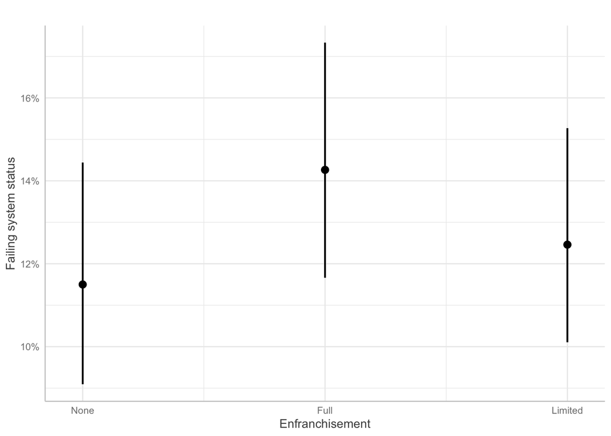

```
##
## Call:
## lm(formula = Total_risk ~ enfranchisement_final + LN_POP + Source,
##     data = Data)
##
## Residuals:
##     Min      1Q  Median      3Q     Max
## -2.6833 -1.0038 -0.2822  0.7595  7.4939
##
## Coefficients:
##                              Estimate Std. Error t value Pr(>|t|)
## (Intercept)                   3.95863    0.11284  35.082  < 2e-16 ***
## enfranchisement_finalFull     0.15674    0.08177   1.917 0.055395 .
## enfranchisement_finalLimited -0.37145    0.07674  -4.840 1.38e-06 ***
## LN_POP                       -0.25222    0.01757 -14.356  < 2e-16 ***
## SourceSW                     -0.28845    0.07542  -3.824 0.000135 ***
## ---
## Signif. codes:  0 '***' 0.001 '**' 0.01 '*' 0.05 '.' 0.1 ' ' 1
##
## Residual standard error: 1.401 on 2272 degrees of freedom
##   (149 observations deleted due to missingness)
## Multiple R-squared:  0.1307, Adjusted R-squared:  0.1292
## F-statistic: 85.43 on 4 and 2272 DF,  p-value: < 2.2e-16
```

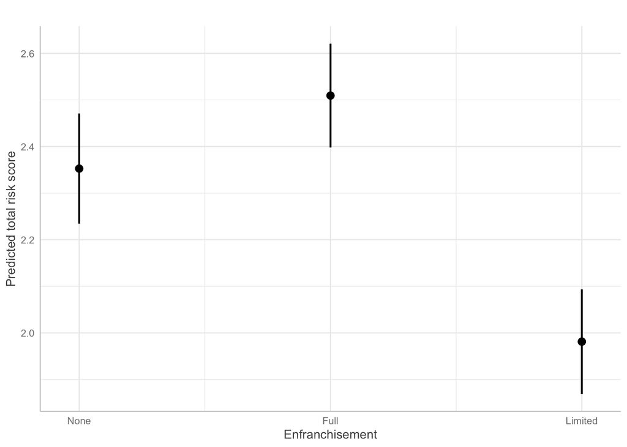

```
##
## Call:
## lm(formula = WEIGHTED_WATER_QUALITY_SCORE ~ enfranchisement_final +
##     LN_POP + Source, data = Data)
##
## Residuals:
##     Min      1Q  Median      3Q     Max
## -0.6266 -0.6059 -0.3268  0.1842  3.8977
##
## Coefficients:
##                               Estimate Std. Error t value Pr(>|t|)
## (Intercept)                   0.638781   0.068139   9.375  < 2e-16 ***
## enfranchisement_finalFull     0.001881   0.049379   0.038    0.970
## enfranchisement_finalLimited -0.013622   0.046343  -0.294    0.769
## LN_POP                       -0.004319   0.010609  -0.407    0.684
## SourceSW                     -0.287613   0.045545  -6.315 3.24e-10 ***
## ---
## Signif. codes:  0 '***' 0.001 '**' 0.01 '*' 0.05 '.' 0.1 ' ' 1
##
## Residual standard error: 0.8463 on 2272 degrees of freedom
##   (149 observations deleted due to missingness)
## Multiple R-squared:  0.02283,    Adjusted R-squared:  0.02111
## F-statistic: 13.27 on 4 and 2272 DF,  p-value: 1.089e-10
```

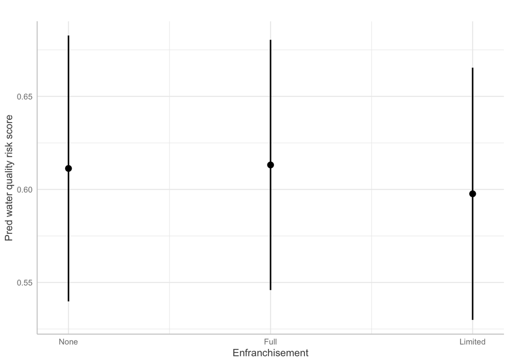

```
##
## Call:
## lm(formula = WEIGHTED_TMF_CAPACITY_SCORE ~ enfranchisement_final +
##     LN_POP + Source + Purchased, data = Data)
##
## Residuals:
##     Min      1Q  Median      3Q     Max
## -0.5605 -0.3207 -0.1059  0.3058  2.3452
##
## Coefficients:
##                               Estimate Std. Error t value Pr(>|t|)
## (Intercept)                   0.640323   0.047636  13.442  < 2e-16 ***
## enfranchisement_finalFull    -0.069740   0.023291  -2.994  0.00278 **
## enfranchisement_finalLimited -0.192603   0.021851  -8.815  < 2e-16 ***
## LN_POP                       -0.033583   0.005108  -6.574 6.05e-11 ***
## SourceSW                      0.012775   0.024966   0.512  0.60893
## PurchasedSelf-produced        0.029588   0.029797   0.993  0.32082
## ---
## Signif. codes:  0 '***' 0.001 '**' 0.01 '*' 0.05 '.' 0.1 ' ' 1
##
## Residual standard error: 0.3986 on 2271 degrees of freedom
##   (149 observations deleted due to missingness)
## Multiple R-squared:  0.05327,    Adjusted R-squared:  0.05118
## F-statistic: 25.56 on 5 and 2271 DF,  p-value: < 2.2e-16
```

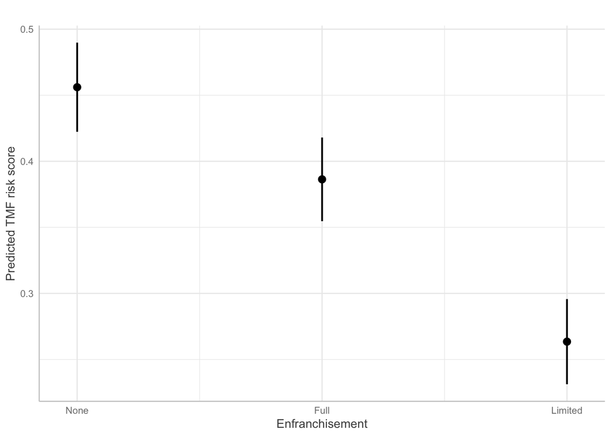

```
##
## Call:
## lm(formula = WEIGHTED_AFFORDABILITY_SCORE ~ enfranchisement_final +
##     LN_POP + Source + Purchased, data = Data)
##
## Residuals:
##     Min      1Q  Median      3Q     Max
## -0.6621 -0.4787 -0.1707  0.2927  1.7771
##
## Coefficients:
##                               Estimate Std. Error t value Pr(>|t|)
## (Intercept)                   0.429296   0.066531   6.453 1.34e-10 ***
## enfranchisement_finalFull     0.100849   0.032521   3.101  0.00195 **
## enfranchisement_finalLimited  0.095725   0.030522   3.136  0.00173 **
## LN_POP                       -0.022937   0.007133  -3.216  0.00132 **
## SourceSW                      0.041342   0.034855   1.186  0.23569
## PurchasedSelf-produced        0.170484   0.041598   4.098 4.31e-05 ***
## ---
## Signif. codes:  0 '***' 0.001 '**' 0.01 '*' 0.05 '.' 0.1 ' ' 1
##
## Residual standard error: 0.5565 on 2270 degrees of freedom
##   (150 observations deleted due to missingness)
## Multiple R-squared:  0.02373,    Adjusted R-squared:  0.02158
## F-statistic: 11.03 on 5 and 2270 DF,  p-value: 1.615e-10
```

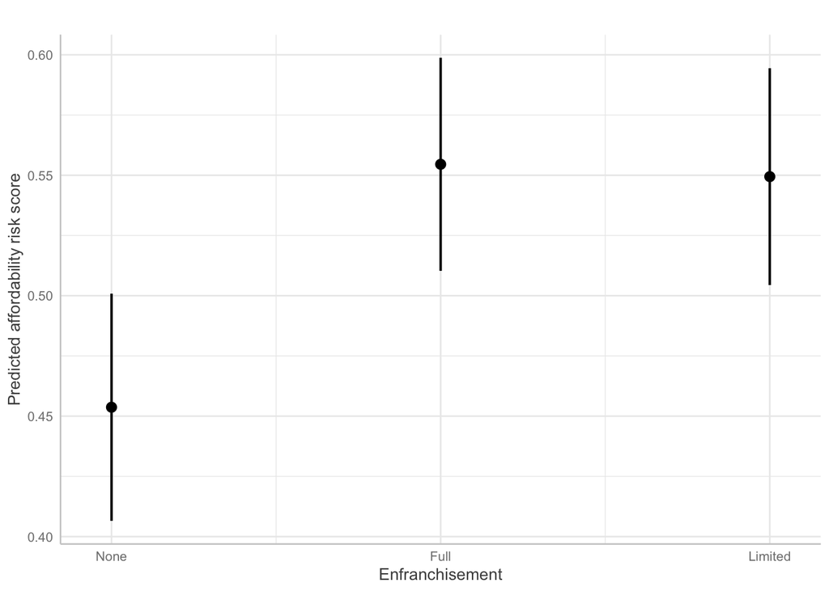

```
##
## Call:
## lm(formula = WEIGHTED_ACCESSIBILITY_SCORE ~ enfranchisement_final +
##     LN_POP + Source + Purchased, data = Data)
##
## Residuals:
##      Min       1Q   Median       3Q      Max
## -1.26347 -0.50545 -0.07448  0.36827  3.01544
##
## Coefficients:
##                               Estimate Std. Error t value Pr(>|t|)
## (Intercept)                   1.682841   0.076741  21.929  < 2e-16 ***
## enfranchisement_finalFull     0.103970   0.037521   2.771  0.00563 **
## enfranchisement_finalLimited -0.246519   0.035201  -7.003 3.28e-12 ***
## LN_POP                       -0.174415   0.008229 -21.194  < 2e-16 ***
## SourceSW                      0.151492   0.040220   3.767  0.00017 ***
## PurchasedSelf-produced        0.281603   0.048002   5.867 5.10e-09 ***
## ---
## Signif. codes:  0 '***' 0.001 '**' 0.01 '*' 0.05 '.' 0.1 ' ' 1
##
## Residual standard error: 0.6422 on 2271 degrees of freedom
##   (149 observations deleted due to missingness)
## Multiple R-squared:  0.2326, Adjusted R-squared:  0.2309
## F-statistic: 137.7 on 5 and 2271 DF,  p-value: < 2.2e-16
```

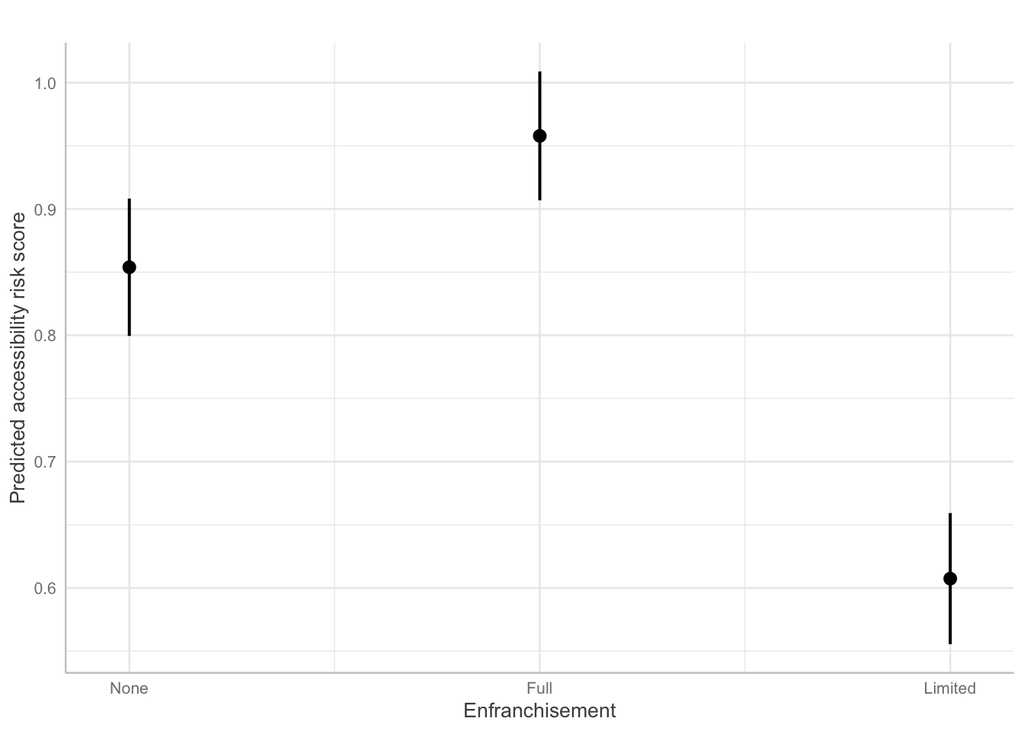

```
##
## Call:
## glm(formula = Application.complete. ~ enfranchisement_final +
##     LN_POP + Source, family = binomial, data = Data)
##
## Deviance Residuals:
##     Min       1Q   Median       3Q      Max
## -2.3982  -0.6493  -0.3756   0.6101   2.7639
##
## Coefficients:
##                              Estimate Std. Error z value Pr(>|z|)
## (Intercept)                  -4.24689    0.20911 -20.309  < 2e-16 ***
## enfranchisement_finalFull     0.31343    0.13451   2.330   0.0198 *
## enfranchisement_finalLimited -0.94596    0.15823  -5.979 2.25e-09 ***
## LN_POP                        0.54718    0.03063  17.865  < 2e-16 ***
## SourceSW                      0.13592    0.12748   1.066   0.2863
## ---
## Signif. codes:  0 '***' 0.001 '**' 0.01 '*' 0.05 '.' 0.1 ' ' 1
##
## (Dispersion parameter for binomial family taken to be 1)
##
##     Null deviance: 3142.3  on 2403  degrees of freedom
## Residual deviance: 2132.7  on 2399  degrees of freedom
##   (22 observations deleted due to missingness)
## AIC: 2142.7
##
## Number of Fisher Scoring iterations: 5
```

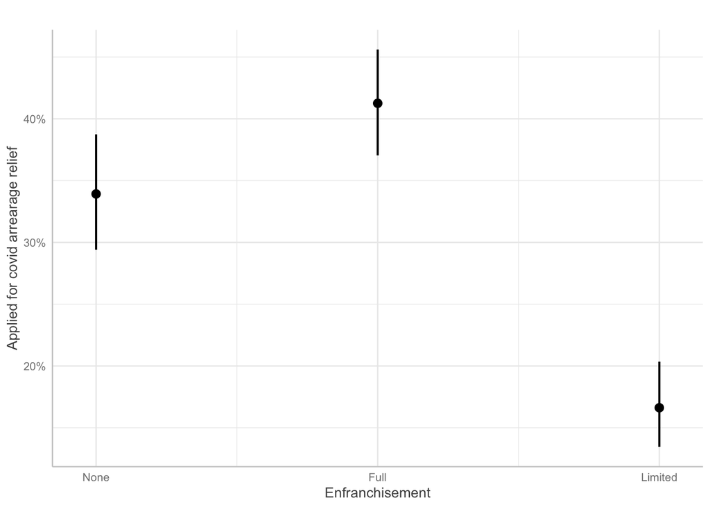

```
##
## Call:
## lm(formula = FUNDING_RECEIVED_SINCE_2017 ~ enfranchisement_final +
##     LN_POP + Source + Purchased, data = Data)
##
## Residuals:
##       Min        1Q    Median        3Q       Max
## -13106825  -2936675   -267019   1160777 682345254
##
## Coefficients:
##                               Estimate Std. Error t value Pr(>|t|)
## (Intercept)                  -13228338    1948700  -6.788 1.42e-11 ***
## enfranchisement_finalFull       428896    1012480   0.424 0.671888
## enfranchisement_finalLimited    926068     995342   0.930 0.352256
## LN_POP                         1188220     188412   6.307 3.38e-10 ***
## SourceSW                       3633893    1074503   3.382 0.000731 ***
## PurchasedSelf-produced         6276512    1277276   4.914 9.52e-07 ***
## ---
## Signif. codes:  0 '***' 0.001 '**' 0.01 '*' 0.05 '.' 0.1 ' ' 1
##
## Residual standard error: 18340000 on 2415 degrees of freedom
##   (5 observations deleted due to missingness)
## Multiple R-squared:  0.03157,    Adjusted R-squared:  0.02956
## F-statistic: 15.74 on 5 and 2415 DF,  p-value: 2.786e-15
```

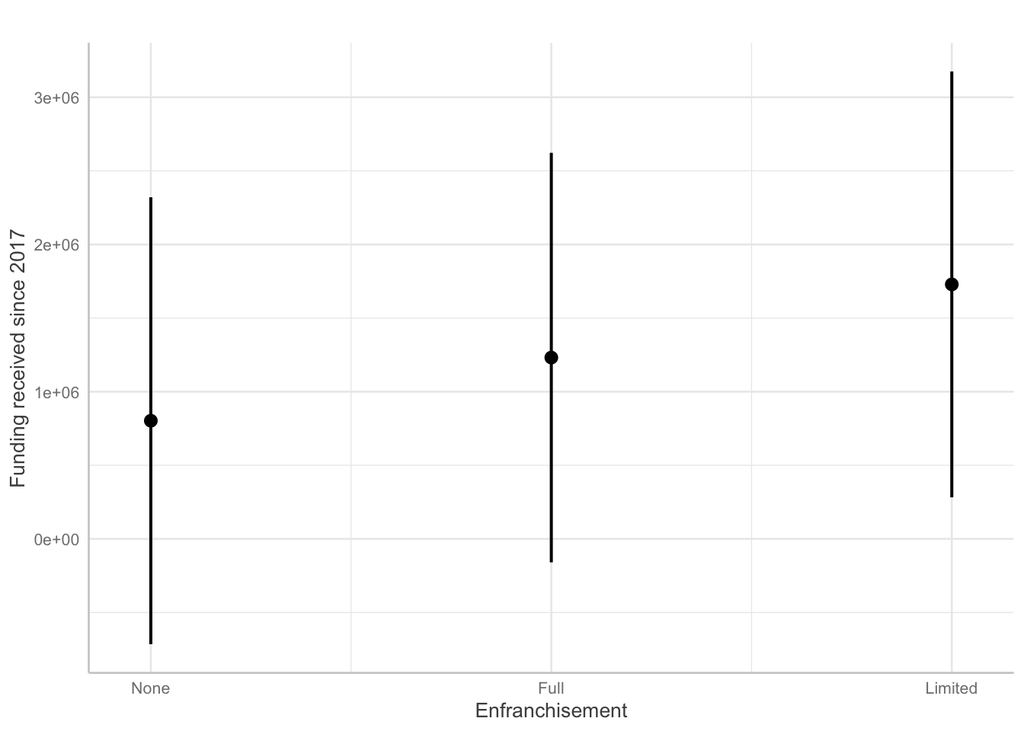

In many ways these results are as predicted, water quality and failing system status don’t offer many insights across enfranchisement types which makes sense as we wouldn’t necessarily expect enfranchisement to influence water quality and water quality is a big factor for failing status. The covid arrearage results align with the hypothesis.

Not sure how to interpret the overall risk score results -> perhaps just confused by the different results related to the various sub-components

A few other results are surprising. That limited enfrachisement systems have better accessibility scores (less risk) is somewhat surprising. I wonder if this relates to water rights/access to surface water? Similarly that TMF risk scores are lowest among these systems is also interesting and perhaps relates to greater resources among some larger water districts and mutual water companies?

Below I dig a bit more some of the other unexpected results starting with affordability. Data quality for the affordability component of the needs assessment is notoriously challenging. A large reason for this is that Mobile Home Park systems regularly don’t charge customers for water but rather incorporate the costs into rent. If we exclude MHPs from the affordability analysis we find that the results are much more aligned with initial expectations although limited enfrachisement systems continue to stick out as being mroe resoruced/high performing.

```
##
## Call:
## lm(formula = WEIGHTED_AFFORDABILITY_SCORE ~ enfranchisement_final +
##     LN_POP + Source + Purchased, data = Data_noMHP)
##
## Residuals:
##     Min      1Q  Median      3Q     Max
## -0.7096 -0.4892 -0.2031  0.3885  1.7320
##
## Coefficients:
##                               Estimate Std. Error t value Pr(>|t|)
## (Intercept)                   0.711016   0.085883   8.279 2.33e-16 ***
## enfranchisement_finalFull    -0.038514   0.044863  -0.858 0.390738
## enfranchisement_finalLimited -0.088856   0.048368  -1.837 0.066356 .
## LN_POP                       -0.039056   0.008001  -4.881 1.14e-06 ***
## SourceSW                      0.024419   0.037336   0.654 0.513158
## PurchasedSelf-produced        0.158508   0.043581   3.637 0.000283 ***
## ---
## Signif. codes:  0 '***' 0.001 '**' 0.01 '*' 0.05 '.' 0.1 ' ' 1
##
## Residual standard error: 0.5765 on 1879 degrees of freedom
##   (146 observations deleted due to missingness)
## Multiple R-squared:  0.0334, Adjusted R-squared:  0.03083
## F-statistic: 12.98 on 5 and 1879 DF,  p-value: 1.915e-12
```

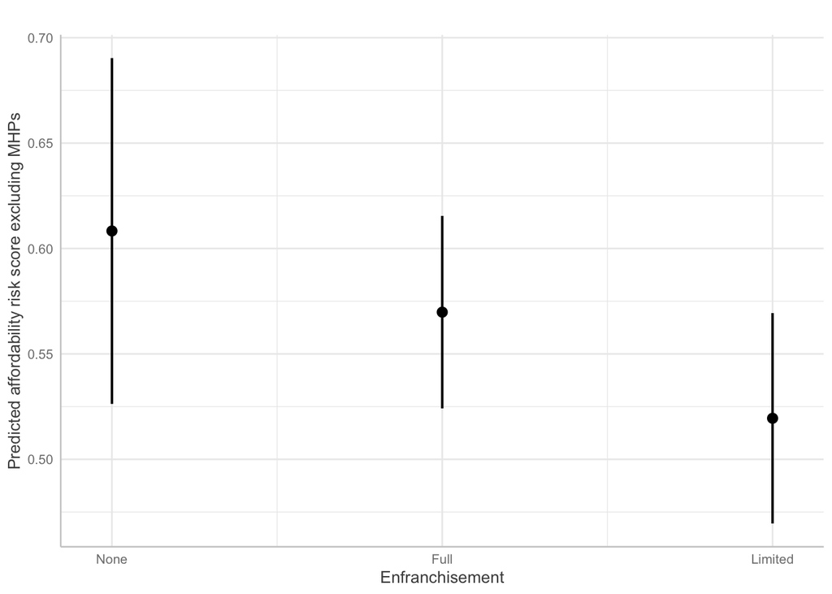

Starting in 2023 the needs assessment also incorporated a new indicator in the affordability risk score for household socioeconomic burden. “The purpose of this risk indicator is to identify water systems that serve communities that have both high levels of poverty and high housing costs for low-income households. These communities may be struggling to pay their current water bill and may have a difficult time shouldering future customer charge increases when their limited disposable income is constrained by high housing costs. This indicator is a composite indicator of two data points: Poverty Prevalence and Housing Burden.” As such, this indicator doesn’t specifically relate to water rates or affordability but rather social vulnerability. If we use one of the other two subindicators instead of the affordability risk score (maintaing use of the data set that does not include Mobile Home Parks) we see similar results for the MHI indicator but for the extreme water bill indicator we see limited enfrisement systems performing worst of all followed by no enfrachisement.

```
##
## Call:
## lm(formula = PERCENT_OF_MEDIAN_HOUSEHOLD_INCOME_MHI_RAW_SCORE ~
##     enfranchisement_final + LN_POP + Source + Purchased, data = Data_noMHP)
##
## Residuals:
##     Min      1Q  Median      3Q     Max
## -0.4589 -0.2758 -0.1494  0.3703  1.0287
##
## Coefficients:
##                               Estimate Std. Error t value Pr(>|t|)
## (Intercept)                   0.527737   0.057033   9.253  < 2e-16 ***
## enfranchisement_finalFull    -0.053237   0.029317  -1.816 0.069557 .
## enfranchisement_finalLimited -0.081867   0.031883  -2.568 0.010320 *
## LN_POP                       -0.053403   0.005303 -10.070  < 2e-16 ***
## SourceSW                      0.079137   0.024737   3.199 0.001404 **
## PurchasedSelf-produced        0.107877   0.028985   3.722 0.000204 ***
## ---
## Signif. codes:  0 '***' 0.001 '**' 0.01 '*' 0.05 '.' 0.1 ' ' 1
##
## Residual standard error: 0.3656 on 1707 degrees of freedom
##   (318 observations deleted due to missingness)
## Multiple R-squared:  0.09239,    Adjusted R-squared:  0.08973
## F-statistic: 34.75 on 5 and 1707 DF,  p-value: < 2.2e-16
```

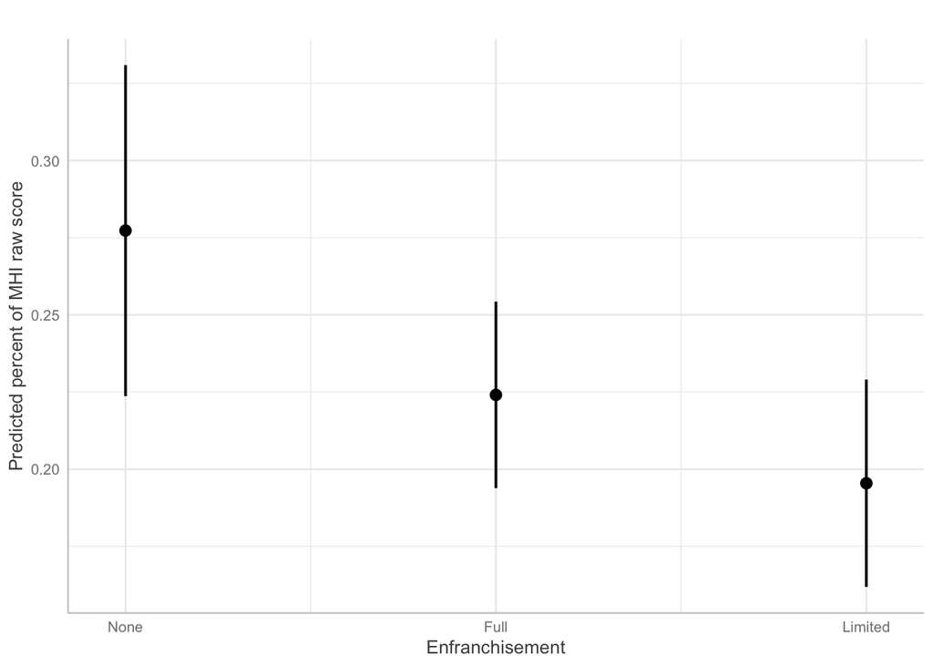

```
##
## Call:
## lm(formula = EXTREME_WATER_BILL_RAW_SCORE ~ enfranchisement_final +
##     LN_POP + Source + Purchased, data = Data_noMHP)
##
## Residuals:
##      Min       1Q   Median       3Q      Max
## -0.35748 -0.17555 -0.09458  0.00931  1.02333
##
## Coefficients:
##                               Estimate Std. Error t value Pr(>|t|)
## (Intercept)                   0.315156   0.045176   6.976 4.32e-12 ***
## enfranchisement_finalFull    -0.008771   0.023223  -0.378    0.706
## enfranchisement_finalLimited  0.035086   0.025253   1.389    0.165
## LN_POP                       -0.038033   0.004200  -9.055  < 2e-16 ***
## SourceSW                      0.097559   0.019595   4.979 7.04e-07 ***
## PurchasedSelf-produced        0.033590   0.022963   1.463    0.144
## ---
## Signif. codes:  0 '***' 0.001 '**' 0.01 '*' 0.05 '.' 0.1 ' ' 1
##
## Residual standard error: 0.2897 on 1710 degrees of freedom
##   (315 observations deleted due to missingness)
## Multiple R-squared:  0.09011,    Adjusted R-squared:  0.08744
## F-statistic: 33.87 on 5 and 1710 DF,  p-value: < 2.2e-16
```

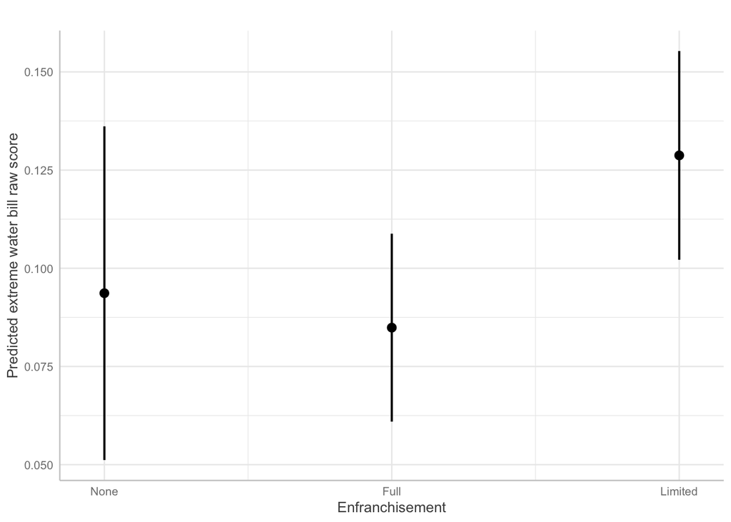

Considering the funding received results, it makes sense that systems that are not failing and not risk would not necessarily be receiving grant funding to the same degree as those that are. Thus below I re-do this analysis but only failing water systems and then for failing and at-risk system. Particularly for failing systems we do see a shift towards full enfranchisement systems receiving more fundingalthough the confidence intervals are large.

```
##
## Call:
## lm(formula = FUNDING_RECEIVED_SINCE_2017 ~ enfranchisement_final +
##     LN_POP + Source + Purchased, data = Data_failingonly)
##
## Residuals:
##      Min       1Q   Median       3Q      Max
## -4825338 -1129985  -285484   323316 26256228
##
## Coefficients:
##                              Estimate Std. Error t value Pr(>|t|)
## (Intercept)                  -3974226    1599892  -2.484   0.0136 *
## enfranchisement_finalFull      823026     552805   1.489   0.1377
## enfranchisement_finalLimited    13625     481223   0.028   0.9774
## LN_POP                         586075     131952   4.442  1.3e-05 ***
## SourceSW                      -372768     566843  -0.658   0.5113
## PurchasedSelf-produced        1247543    1290762   0.967   0.3346
## ---
## Signif. codes:  0 '***' 0.001 '**' 0.01 '*' 0.05 '.' 0.1 ' ' 1
##
## Residual standard error: 3146000 on 275 degrees of freedom
## Multiple R-squared:  0.1428, Adjusted R-squared:  0.1272
## F-statistic: 9.164 on 5 and 275 DF,  p-value: 4.441e-08
```

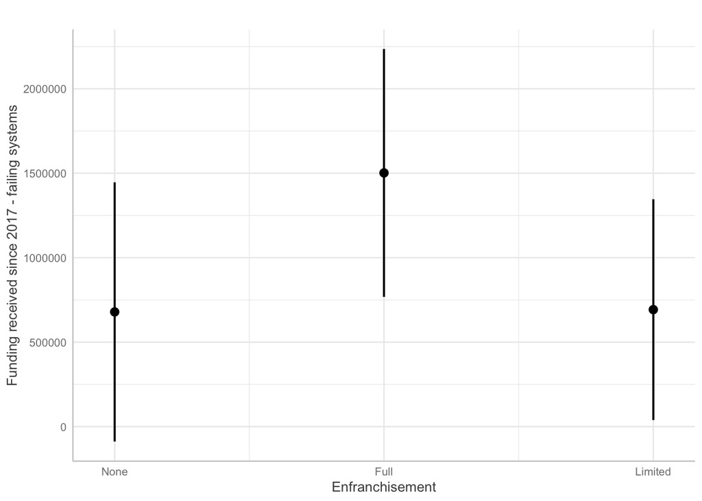

```
##
## Call:
## lm(formula = FUNDING_RECEIVED_SINCE_2017 ~ enfranchisement_final +
##     LN_POP + Source + Purchased, data = Data_failingoratrisk)
##
## Residuals:
##      Min       1Q   Median       3Q      Max
## -4603668  -875904  -228695   328407 26430308
##
## Coefficients:
##                              Estimate Std. Error t value Pr(>|t|)
## (Intercept)                  -4655564    1005690  -4.629 5.45e-06 ***
## enfranchisement_finalFull      178336     413494   0.431   0.6666
## enfranchisement_finalLimited   130095     375394   0.347   0.7292
## LN_POP                         662099     107828   6.140 2.58e-09 ***
## SourceSW                      -352271     412206  -0.855   0.3934
## PurchasedSelf-produced        1650257     691022   2.388   0.0175 *
## ---
## Signif. codes:  0 '***' 0.001 '**' 0.01 '*' 0.05 '.' 0.1 ' ' 1
##
## Residual standard error: 2614000 on 303 degrees of freedom
## Multiple R-squared:  0.1651, Adjusted R-squared:  0.1513
## F-statistic: 11.98 on 5 and 303 DF,  p-value: 1.345e-10
```

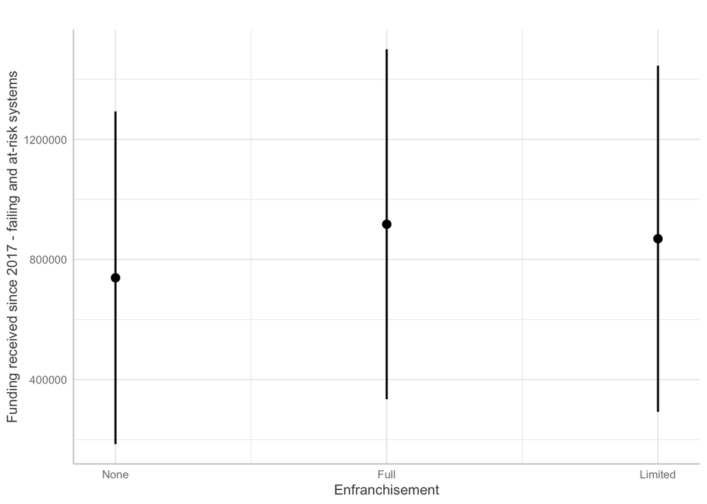

Lastly I consider which Californians are served by systems with different types of enfranchisement looking at the association between enfranchisement and calenviroscreen scores and enfranchisement and the socioeconomic burden indicators from the needs assessment. No “enfranchisement” systems are associated with higher cal enviro scores. Limited enfrachisement systems, however, as associated with lower scores. The results for socioeconomic burden are similar.

```
##
## Call:
## lm(formula = CALENVIRO_SCREEN_SCORE ~ enfranchisement_final +
##     LN_POP + Source + Purchased, data = Data)
##
## Residuals:
##     Min      1Q  Median      3Q     Max
## -29.116 -10.069  -3.164   7.255  57.727
##
## Coefficients:
##                              Estimate Std. Error t value Pr(>|t|)
## (Intercept)                   25.7333     1.5154  16.981  < 2e-16 ***
## enfranchisement_finalFull     -1.3252     0.7931  -1.671   0.0949 .
## enfranchisement_finalLimited  -4.6313     0.7838  -5.909 3.96e-09 ***
## LN_POP                         0.8789     0.1459   6.025 1.96e-09 ***
## SourceSW                      -7.0755     0.8334  -8.490  < 2e-16 ***
## PurchasedSelf-produced        -3.8670     0.9829  -3.934 8.59e-05 ***
## ---
## Signif. codes:  0 '***' 0.001 '**' 0.01 '*' 0.05 '.' 0.1 ' ' 1
##
## Residual standard error: 13.88 on 2276 degrees of freedom
##   (144 observations deleted due to missingness)
## Multiple R-squared:  0.06249,    Adjusted R-squared:  0.06043
## F-statistic: 30.34 on 5 and 2276 DF,  p-value: < 2.2e-16
```

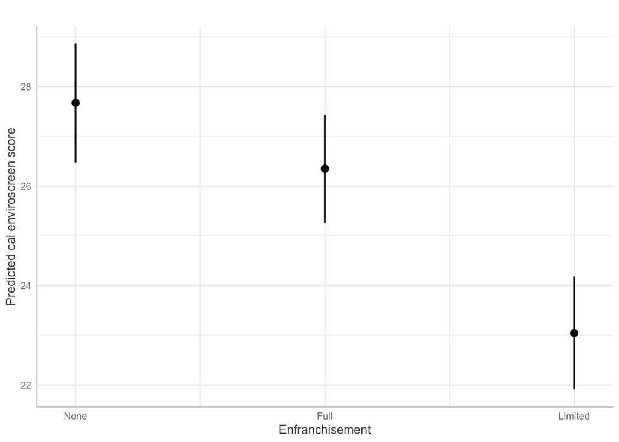

```
##
## Call:
## lm(formula = HOUSEHOLD_SOCIOECONOMIC_BURDEN_RAW_SCORE ~ enfranchisement_final +
##     LN_POP + Source + Purchased, data = Data)
##
## Residuals:
##      Min       1Q   Median       3Q      Max
## -0.59950 -0.35907  0.01226  0.46713  0.79502
##
## Coefficients:
##                               Estimate Std. Error t value Pr(>|t|)
## (Intercept)                   0.307016   0.048458   6.336 2.84e-10 ***
## enfranchisement_finalFull    -0.083344   0.023689  -3.518 0.000443 ***
## enfranchisement_finalLimited -0.138417   0.022250  -6.221 5.87e-10 ***
## LN_POP                        0.020423   0.005202   3.926 8.89e-05 ***
## SourceSW                     -0.074594   0.025377  -2.939 0.003322 **
## PurchasedSelf-produced        0.065835   0.030287   2.174 0.029833 *
## ---
## Signif. codes:  0 '***' 0.001 '**' 0.01 '*' 0.05 '.' 0.1 ' ' 1
##
## Residual standard error: 0.405 on 2261 degrees of freedom
##   (159 observations deleted due to missingness)
## Multiple R-squared:  0.03388,    Adjusted R-squared:  0.03175
## F-statistic: 15.86 on 5 and 2261 DF,  p-value: 2.209e-15
```

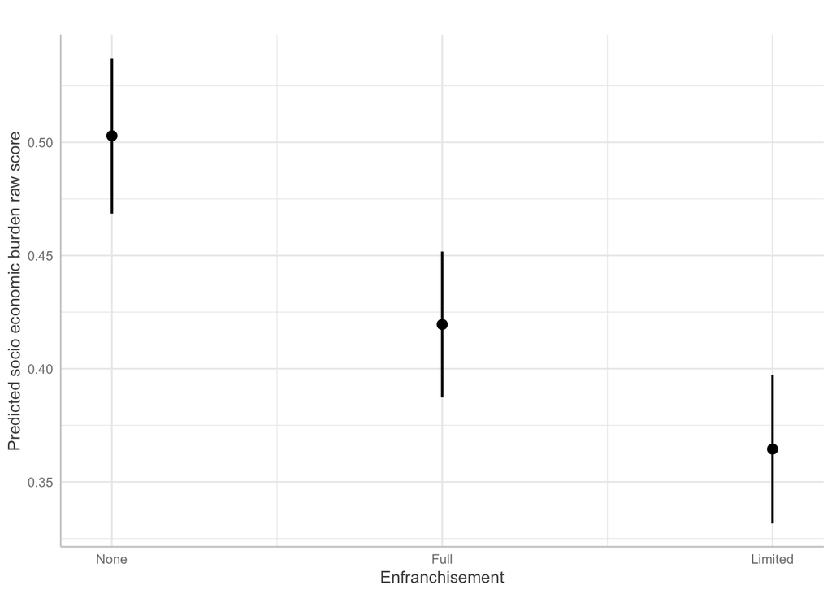

####QUESTIONS TO ANSWER LATER : 1) Use weighted or unweighted risk assessment scores? Doesnt’ matter for results.